# Predicting NBA All-Stars for the 2023-2024 Season

[figure not shown]

**Project Members: Anirudha Uppugunduri**

*This project is independently completed by myself, Anirudha Uppugunduri, and is intended for the usage of CMSC320: Introduction to Data Science of the University of Maryland. All code and prose is written by me. All data sources and resources will be linked down below for reference purposes.*

*The study is to provide insights into how to predict and visualize similarities between data and statistics from the National Basketball Association. This project is not completely accurate and will not 100% predict the All-Star players for the 2023-2024 NBA Season.*

## Introduction

The [National Basketball Association (NBA)](https://www.nba.com/) is the highest level of professional basketball in the United States and premier league throughout the entire world. As such, the competition within the NBA is at its peak where players all over the world are paid up to hundreds of millions of dollars to compete. While winning the annual national championship is the highest achievement, there are many other achievements and awards given out throughout every season. These include Most Valuable Player (MVP), Most Improved Player (MIP), Defensive Player of the Year (DPOY), Rookie of the Year (ROY), etc.

The award this study looks to delve into will be the All-Star honors. To describe the All-Star honors, it is recognition given to 12 players for their high-level of play determined by a combination of fan, player, and media voting. The voting procedures are based on the positions that each player plays. Because each position is not the exact same, voting perceptions are a little bit different. For example, taller players generally play the power forward or center position, so they are expected to have more defensive capabilities due to their height as opposed to shorter players who may play the point guard, shooting guard or small forward positions who are expected to score more and have lesser defensive capabilities. However, this is not always the case though as more and more players are changing up their playstyles and are not strictly focused on these criterias which were more enforced in the past (before mid 2010s).

Voting is based on "frontcourt" and "backcourt". The frontcourt consists of three positions: small forward, power forward and center. The backcourt consists of two positions: point guard and shooting guard. Based on how much better they are relative to their peers, these players would end up getting more votes to become All-Stars. These players will then play in the All-Star game during the NBA All-Star weekend. As there are two conferences in the NBA, the eastern and western, there are a total of 24 players chosen as All-Stars. If by any chance they are unable to play in the All-Star weekend due to injury, then a replacement will be selected by the NBA commissioner.

Understanding and discovering patterns to predict future All-Stars for future seasons can lead to many important realizations. Players who are generally All-Stars gain a much more larger following due to their recognition in skill which allow for more traction within their city and eyes to view their games. This brings in more revenue and money for their particular city and allows them to gain a much more stronger basis to qualify for larger contracts as they are more valuable to their particular franchise. To contend for championships, a team must recognize the worth of their players and try to build balanced rosters under the salary cap.

## Step 1: Data Collection

As this is the first step of the lifecycle, we need a proper data source to collect information. [Basketball-Reference](https://www.basketball-reference.com/) provides a wide variety of statistics and is very trusted as it directly takes stats from the NBA. Since we are visualizing and looking at All-Star statistics, the best dataset of statistics to look at would be player stats from particular NBA seasons. As the game changes very frequently, we'll be using statistics from the past 5 years to act as a baseline.

We'll be using [iPython](https://ipython.org/), [Jupyter Notebook](https://jupyter.org/) and the [Python](https://www.python.org/about/) programming language as our platforms to collect the information and build visualizations and models to develop the project and understanding. The first thing to do is to import some libraries that we need to use throughout the final tutorial.

**Imports**

```python
import numpy as np
import pandas as pd
import seaborn as sns
import matplotlib.pyplot as plt
import requests
import statsmodels.api as sm
import copy

from bs4 import BeautifulSoup
from adjustText import adjust_text
from sklearn.decomposition import PCA
from sklearn.preprocessing import StandardScaler
from sklearn.linear_model import LinearRegression

# Display Settings
pd.set_option('display.max_rows', None)
pd.set_option('display.max_columns', None)
pd.set_option('mode.chained_assignment', None)
```

We'll use these links to get the statistics of each player from the past 5 years. Since new players are drafted in the league every single time, each dataframe does not contain the same players.

[NBA Player Statistics from the 2022-2023 Season](https://www.basketball-reference.com/leagues/NBA_2023_per_game.html)  
[NBA Player Statistics from the 2021-2022 Season](https://www.basketball-reference.com/leagues/NBA_2022_per_game.html)  
[NBA Player Statistics from the 2020-2021 Season](https://www.basketball-reference.com/leagues/NBA_2021_per_game.html)  
[NBA Player Statistics from the 2019-2020 Season](https://www.basketball-reference.com/leagues/NBA_2020_per_game.html)  
[NBA Player Statistics from the 2018-2019 Season](https://www.basketball-reference.com/leagues/NBA_2019_per_game.html)

```python
url2023 = "https://www.basketball-reference.com/leagues/NBA_2023_per_game.html"
url2022 = "https://www.basketball-reference.com/leagues/NBA_2022_per_game.html"
url2021 = "https://www.basketball-reference.com/leagues/NBA_2021_per_game.html"
url2020 = "https://www.basketball-reference.com/leagues/NBA_2020_per_game.html"
url2019 = "https://www.basketball-reference.com/leagues/NBA_2019_per_game.html"

# Requesting information
resp2023 = requests.get(url2023)
resp2022 = requests.get(url2022)
resp2021 = requests.get(url2021)
resp2020 = requests.get(url2020)
resp2019 = requests.get(url2019)
```

```python
# Using BeautifulSoup to convert to then find the HTML tables
soup2023 = BeautifulSoup(resp2023.content, 'html.parser')
soup2022 = BeautifulSoup(resp2022.content, 'html.parser')
soup2021 = BeautifulSoup(resp2021.content, 'html.parser')
soup2020 = BeautifulSoup(resp2020.content, 'html.parser')
soup2019 = BeautifulSoup(resp2019.content, 'html.parser')

# Accessing the HTML tables
table2023 = soup2023.find('table', {'class': 'sortable stats_table'})
table2022 = soup2022.find('table', {'class': 'sortable stats_table'})
table2021 = soup2021.find('table', {'class': 'sortable stats_table'})
table2020 = soup2020.find('table', {'class': 'sortable stats_table'})
table2019 = soup2019.find('table', {'class': 'sortable stats_table'})
```

```python
# Getting the columns of the tables to use as part of the dataframe
columns2023 = [th.getText() for th in table2023.findAll('tr')[0].findAll('th')]
columns2023 = columns2023[1:]

columns2022 = [th.getText() for th in table2022.findAll('tr')[0].findAll('th')]
columns2022 = columns2022[1:]

columns2021 = [th.getText() for th in table2021.findAll('tr')[0].findAll('th')]
columns2021 = columns2021[1:]

columns2020 = [th.getText() for th in table2020.findAll('tr')[0].findAll('th')]
columns2020 = columns2020[1:]

columns2019 = [th.getText() for th in table2019.findAll('tr')[0].findAll('th')]
columns2019 = columns2019[1:]

# Collecting the stats of each year in lists
players_stats2023 = []
players_stats2022 = []
players_stats2021 = []
players_stats2020 = []
players_stats2019 = []

# Removing the first row as it was unnecessary
rows2023 = table2023.findAll('tr')[1:]
rows2022 = table2022.findAll('tr')[1:]
rows2021 = table2021.findAll('tr')[1:]
rows2020 = table2020.findAll('tr')[1:]
rows2019 = table2019.findAll('tr')[1:]

# Getting each row value and then collecting the stats and adding it to the list
for row in rows2023:
    stats = [td.getText() for td in row.findAll('td')]
    players_stats2023.append(stats)

for row in rows2022:
    stats = [td.getText() for td in row.findAll('td')]
    players_stats2022.append(stats)

for row in rows2021:
    stats = [td.getText() for td in row.findAll('td')]
    players_stats2021.append(stats)

for row in rows2020:
    stats = [td.getText() for td in row.findAll('td')]
    players_stats2020.append(stats)

for row in rows2019:
    stats = [td.getText() for td in row.findAll('td')]
    players_stats2019.append(stats)

# Converting to dataframes
df2023 = pd.DataFrame(players_stats2023, columns=columns2023)
df2022 = pd.DataFrame(players_stats2022, columns=columns2022)
df2021 = pd.DataFrame(players_stats2021, columns=columns2021)
df2020 = pd.DataFrame(players_stats2020, columns=columns2020)
df2019 = pd.DataFrame(players_stats2019, columns=columns2019)
```

We'll also use these sources to scrape the All-Stars for each year from 2019-2023.

[2023 NBA All-Stars](https://www.basketball-reference.com/allstar/NBA_2023.html)  
[2022 NBA All-Stars](https://www.basketball-reference.com/allstar/NBA_2022.html)  
[2021 NBA All-Stars](https://www.basketball-reference.com/allstar/NBA_2021.html)  
[2020 NBA All-Stars](https://www.basketball-reference.com/allstar/NBA_2020.html)  
[2019 NBA All-Stars](https://www.basketball-reference.com/allstar/NBA_2019.html)

```python
url2023 = "https://www.basketball-reference.com/allstar/NBA_2023.html"
url2022 = "https://www.basketball-reference.com/allstar/NBA_2022.html"
url2021 = "https://www.basketball-reference.com/allstar/NBA_2021.html"
url2020 = "https://www.basketball-reference.com/allstar/NBA_2020.html"
url2019 = "https://www.basketball-reference.com/allstar/NBA_2019.html"

# Requesting information
resp2023 = requests.get(url2023)
resp2022 = requests.get(url2022)
resp2021 = requests.get(url2021)
resp2020 = requests.get(url2020)
resp2019 = requests.get(url2019)
```

```python
# Using BeautifulSoup to convert to then find the HTML tables
soup2023 = BeautifulSoup(resp2023.content, 'html.parser')
soup2022 = BeautifulSoup(resp2022.content, 'html.parser')
soup2021 = BeautifulSoup(resp2021.content, 'html.parser')
soup2020 = BeautifulSoup(resp2020.content, 'html.parser')
soup2019 = BeautifulSoup(resp2019.content, 'html.parser')

# Retrieving each All-Star player
player_elements2023 = soup2023.find_all('th', {'csk': True})
allstars2023 = [player.a.text for player in player_elements2023 if player.a]

player_elements2022 = soup2022.find_all('th', {'csk': True})
allstars2022 = [player.a.text for player in player_elements2022 if player.a]

player_elements2021 = soup2021.find_all('th', {'csk': True})
allstars2021 = [player.a.text for player in player_elements2021 if player.a]

player_elements2020 = soup2020.find_all('th', {'csk': True})
allstars2020 = [player.a.text for player in player_elements2020 if player.a]

player_elements2019 = soup2019.find_all('th', {'csk': True})
allstars2019 = [player.a.text for player in player_elements2019 if player.a]
```

As mentioned within the introduction, the way All-Stars are voted in are based on the fans, the players, and the media. Since there are millions of fans that vote which would outweigh the players and media, Basketball-Reference provides a ranking based on the number of votes which we will conveniently end up using later to process the votes and determine the weightage of voting to create visualizations.

In the meantime, we'll pull the information from these links and parse into dataframes. These links are the voting statistics per player for based on the conference they play in and the position they play either in the frontcourt or the backcourt. Note that voting isn't based on a particular position but rather the frontcourt and backcourt positions combined.

[2023 Frontcourt, Eastern Conference](https://www.basketball-reference.com/allstar/NBA_2023_voting-frontcourt-eastern-conference.html)  
[2023 Frontcourt, Western Conference](https://www.basketball-reference.com/allstar/NBA_2023_voting-frontcourt-western-conference.html)  
[2023 Backcourt, Eastern Conference](https://www.basketball-reference.com/allstar/NBA_2023_voting-backcourt-eastern-conference.html)  
[2023 Backcourt, Western Conference](https://www.basketball-reference.com/allstar/NBA_2023_voting-backcourt-western-conference.html)

[2022 Frontcourt, Eastern Conference](https://www.basketball-reference.com/allstar/NBA_2022_voting-frontcourt-eastern-conference.html)  
[2022 Frontcourt, Western Conference](https://www.basketball-reference.com/allstar/NBA_2022_voting-frontcourt-western-conference.html)  
[2022 Backcourt, Eastern Conference](https://www.basketball-reference.com/allstar/NBA_2022_voting-backcourt-eastern-conference.html)  
[2022 Backcourt, Western Conference](https://www.basketball-reference.com/allstar/NBA_2022_voting-backcourt-western-conference.html)

[2021 Frontcourt, Eastern Conference](https://www.basketball-reference.com/allstar/NBA_2021_voting-frontcourt-eastern-conference.html)  
[2021 Frontcourt, Western Conference](https://www.basketball-reference.com/allstar/NBA_2021_voting-frontcourt-western-conference.html)  
[2021 Backcourt, Eastern Conference](https://www.basketball-reference.com/allstar/NBA_2021_voting-backcourt-eastern-conference.html)  
[2021 Backcourt, Western Conference](https://www.basketball-reference.com/allstar/NBA_2021_voting-backcourt-western-conference.html)

[2020 Frontcourt, Eastern Conference](https://www.basketball-reference.com/allstar/NBA_2020_voting-frontcourt-eastern-conference.html)  
[2020 Frontcourt, Western Conference](https://www.basketball-reference.com/allstar/NBA_2020_voting-frontcourt-western-conference.html)  
[2020 Backcourt, Eastern Conference](https://www.basketball-reference.com/allstar/NBA_2020_voting-backcourt-eastern-conference.html)  
[2020 Backcourt, Western Conference](https://www.basketball-reference.com/allstar/NBA_2020_voting-backcourt-western-conference.html)

[2019 Frontcourt, Eastern Conference](https://www.basketball-reference.com/allstar/NBA_2019_voting-frontcourt-eastern-conference.html)  
[2019 Frontcourt, Western Conference](https://www.basketball-reference.com/allstar/NBA_2019_voting-frontcourt-western-conference.html)  
[2019 Backcourt, Eastern Conference](https://www.basketball-reference.com/allstar/NBA_2019_voting-backcourt-eastern-conference.html)  
[2019 Backcourt, Western Conference](https://www.basketball-reference.com/allstar/NBA_2019_voting-backcourt-western-conference.html)

```python
front_ecf_url2023 = "https://www.basketball-reference.com/allstar/NBA_2023_voting-frontcourt-eastern-conference.html"
front_wcf_url2023 = "https://www.basketball-reference.com/allstar/NBA_2023_voting-frontcourt-western-conference.html"
back_ecf_url2023 = "https://www.basketball-reference.com/allstar/NBA_2023_voting-backcourt-eastern-conference.html"
back_wcf_url2023 = "https://www.basketball-reference.com/allstar/NBA_2023_voting-backcourt-western-conference.html"

front_ecf_url2022 = "https://www.basketball-reference.com/allstar/NBA_2022_voting-frontcourt-eastern-conference.html"
front_wcf_url2022 = "https://www.basketball-reference.com/allstar/NBA_2022_voting-frontcourt-western-conference.html"
back_ecf_url2022 = "https://www.basketball-reference.com/allstar/NBA_2022_voting-backcourt-eastern-conference.html"
back_wcf_url2022 = "https://www.basketball-reference.com/allstar/NBA_2022_voting-backcourt-western-conference.html"

front_ecf_url2021 = "https://www.basketball-reference.com/allstar/NBA_2021_voting-frontcourt-eastern-conference.html"
front_wcf_url2021 = "https://www.basketball-reference.com/allstar/NBA_2021_voting-frontcourt-western-conference.html"
back_ecf_url2021 = "https://www.basketball-reference.com/allstar/NBA_2021_voting-backcourt-eastern-conference.html"
back_wcf_url2021 = "https://www.basketball-reference.com/allstar/NBA_2021_voting-backcourt-western-conference.html"

front_ecf_url2020 = "https://www.basketball-reference.com/allstar/NBA_2020_voting-frontcourt-eastern-conference.html"
front_wcf_url2020 = "https://www.basketball-reference.com/allstar/NBA_2020_voting-frontcourt-western-conference.html"
back_ecf_url2020 = "https://www.basketball-reference.com/allstar/NBA_2020_voting-backcourt-eastern-conference.html"
back_wcf_url2020 = "https://www.basketball-reference.com/allstar/NBA_2020_voting-backcourt-western-conference.html"

front_ecf_url2019 = "https://www.basketball-reference.com/allstar/NBA_2019_voting-frontcourt-eastern-conference.html"
front_wcf_url2019 = "https://www.basketball-reference.com/allstar/NBA_2019_voting-frontcourt-western-conference.html"
back_ecf_url2019 = "https://www.basketball-reference.com/allstar/NBA_2019_voting-backcourt-eastern-conference.html"
back_wcf_url2019 = "https://www.basketball-reference.com/allstar/NBA_2019_voting-backcourt-western-conference.html"

# Requesting information
resp2023_front_ecf = requests.get(front_ecf_url2023)
resp2023_front_wcf = requests.get(front_wcf_url2023)
resp2023_back_ecf = requests.get(back_ecf_url2023)
resp2023_back_wcf = requests.get(back_wcf_url2023)

resp2022_front_ecf = requests.get(front_ecf_url2022)
resp2022_front_wcf = requests.get(front_wcf_url2022)
resp2022_back_ecf = requests.get(back_ecf_url2022)
resp2022_back_wcf = requests.get(back_wcf_url2022)

resp2021_front_ecf = requests.get(front_ecf_url2021)
resp2021_front_wcf = requests.get(front_wcf_url2021)
resp2021_back_ecf = requests.get(back_ecf_url2021)
resp2021_back_wcf = requests.get(back_wcf_url2021)

resp2020_front_ecf = requests.get(front_ecf_url2020)
resp2020_front_wcf = requests.get(front_wcf_url2020)
resp2020_back_ecf = requests.get(back_ecf_url2020)
resp2020_back_wcf = requests.get(back_wcf_url2020)

resp2019_front_ecf = requests.get(front_ecf_url2019)
resp2019_front_wcf = requests.get(front_wcf_url2019)
resp2019_back_ecf = requests.get(back_ecf_url2019)
resp2019_back_wcf = requests.get(back_wcf_url2019)
```

```python
# Creating a dictionary based on soup objects
soup_dict = {
    'front_ecf_2023': BeautifulSoup(resp2023_front_ecf.content, 'html.parser'),
    'front_wcf_2023': BeautifulSoup(resp2023_front_wcf.content, 'html.parser'),
    'back_ecf_2023': BeautifulSoup(resp2023_back_ecf.content, 'html.parser'),
    'back_wcf_2023': BeautifulSoup(resp2023_back_wcf.content, 'html.parser'),
    'front_ecf_2022': BeautifulSoup(resp2022_front_ecf.content, 'html.parser'),
    'front_wcf_2022': BeautifulSoup(resp2022_front_wcf.content, 'html.parser'),
    'back_ecf_2022': BeautifulSoup(resp2022_back_ecf.content, 'html.parser'),
    'back_wcf_2022': BeautifulSoup(resp2022_back_wcf.content, 'html.parser'),
    'front_ecf_2021': BeautifulSoup(resp2021_front_ecf.content, 'html.parser'),
    'front_wcf_2021': BeautifulSoup(resp2021_front_wcf.content, 'html.parser'),
    'back_ecf_2021': BeautifulSoup(resp2021_back_ecf.content, 'html.parser'),
    'back_wcf_2021': BeautifulSoup(resp2021_back_wcf.content, 'html.parser'),
    'front_ecf_2020': BeautifulSoup(resp2020_front_ecf.content, 'html.parser'),
    'front_wcf_2020': BeautifulSoup(resp2020_front_wcf.content, 'html.parser'),
    'back_ecf_2020': BeautifulSoup(resp2020_back_ecf.content, 'html.parser'),
    'back_wcf_2020': BeautifulSoup(resp2020_back_wcf.content, 'html.parser'),
    'front_ecf_2019': BeautifulSoup(resp2019_front_ecf.content, 'html.parser'),
    'front_wcf_2019': BeautifulSoup(resp2019_front_wcf.content, 'html.parser'),
    'back_ecf_2019': BeautifulSoup(resp2019_back_ecf.content, 'html.parser'),
    'back_wcf_2019': BeautifulSoup(resp2019_back_wcf.content, 'html.parser')
}

# Extracting the information from the content (Very messy)
df_dict = {}
for key, soup in soup_dict.items():
    player_data = []
    for row in soup.find_all("tr"):
        player_row = {}
        for cell in row.find_all(['th', 'td']):
            data_stat = cell.attrs.get('data-stat')
            if cell.a:
                value = cell.a.get_text()
            else:
                value = cell.get_text()
            player_row[data_stat] = value
        player_data.append(player_row)

    df_dict[key] = pd.DataFrame(player_data)
```

## Step 2: Data Processing

```python
# Dropping specific columns
df2023.drop(['Tm', 'MP', 'G', 'GS', 'FG', 'FGA', '3P', '3PA', '2P', '2PA', 'FT', 'FTA', 'ORB', 'DRB', 'TOV', 'PF'], axis=1, inplace=True)
df2022.drop(['Tm', 'MP', 'G', 'GS', 'FG', 'FGA', '3P', '3PA', '2P', '2PA', 'FT', 'FTA', 'ORB', 'DRB', 'TOV', 'PF'], axis=1, inplace=True)
df2021.drop(['Tm', 'MP', 'G', 'GS', 'FG', 'FGA', '3P', '3PA', '2P', '2PA', 'FT', 'FTA', 'ORB', 'DRB', 'TOV', 'PF'], axis=1, inplace=True)
df2020.drop(['Tm', 'MP', 'G', 'GS', 'FG', 'FGA', '3P', '3PA', '2P', '2PA', 'FT', 'FTA', 'ORB', 'DRB', 'TOV', 'PF'], axis=1, inplace=True)
df2019.drop(['Tm', 'MP', 'G', 'GS', 'FG', 'FGA', '3P', '3PA', '2P', '2PA', 'FT', 'FTA', 'ORB', 'DRB', 'TOV', 'PF'], axis=1, inplace=True)
```

We now need to clean some of the data from the dataframes. There are some empty columns, and some blank indexes we need to fill in with 0 as they are empty strings. There also seems to be multiple rows of the same player show up, which means they have played for multiple teams in the same year as they were traded, so we'll average out and add them as one entry.

```python
dfs = [df2023, df2022, df2021, df2020, df2019]


for i in range(len(dfs)):
    # Drop rows with any NaN values and fill out empty holes
    dfs[i].dropna(how='any', inplace=True)
    dfs[i].replace('', 0.000, inplace=True)

    # Get duplicate players
    counts = dfs[i]['Player'].value_counts()
    duplicate_players = counts[counts > 1].index.tolist()

    # For each duplicate player find all their rows and find the average of their statistics
    for player in duplicate_players:
        player_rows = dfs[i][dfs[i]['Player'] == player]
        player_name = player_rows['Player'].iloc[0]
        player_pos = player_rows['Pos'].iloc[0]

        stats_columns = player_rows.columns.difference(['Player', 'Pos'])

        for col in stats_columns:
            player_rows[col] = player_rows[col].astype(float)

        averaged_stats = player_rows[stats_columns].mean()
        new_row = pd.DataFrame([{'Player': player_name, 'Pos': player_pos, **averaged_stats.to_dict()}])

        # Dropping rows of the current player
        indices_to_drop = dfs[i][dfs[i]['Player'] == player].index
        dfs[i].drop(indices_to_drop, inplace=True)

        # Adding new row of the current player
        dfs[i] = pd.concat([dfs[i], new_row], ignore_index=True)

df2023, df2022, df2021, df2020, df2019 = dfs
```

```python
# Currently, they look as such:
df2023
```

[output not shown]

[output cut: 509 more lines]

We also need to fix the All-Stars from the previous years because some were injured or were unable to play due to contracting Covid-19, and so they don't show up as part of the initial table. Since the parsing for this is a bit tedious, we'll manually add them as part of our lists for each year.

```python
# Manually adding All-Stars
allstars2023.extend(["Kevin Durant", "Stephen Curry", "Zion Williamson"])
allstars2022.extend(["Kevin Durant", "Draymond Green", "James Harden", "Donovan Mitchell"])
allstars2021.extend(["Devin Booker", "Anthony Davis", "Kevin Durant", "Joel Embiid", "Ben Simmons"])
allstars2020.extend(["Damian Lillard"])
allstars2019.extend(["Victor Oladipo"])
```

Now, we want to see the statistics of each and every player who was an All-Star from each year and reformat that into a new dataframe.

```python
# Filtering players who are only All-Stars
df2023_AS = df2023[df2023['Player'].isin(allstars2023)]
df2022_AS = df2022[df2022['Player'].isin(allstars2022)]
df2021_AS = df2021[df2021['Player'].isin(allstars2021)]
df2020_AS = df2020[df2020['Player'].isin(allstars2020)]
df2019_AS = df2019[df2019['Player'].isin(allstars2019)]
```

We also need to check if there are players who are listed multiple times. If a player is listed multiple times, it means that they were traded during the season and have played for multiple teams in one season. To ensure the data will not get confused by the multiple entries of these players, we will take an average of their current statistics and place them as one entry.

```python
# Getting the averages of the necessary columns and grouping together by player and then refiltering the dataframes
cols_to_convert = ['Age', 'FG%', '3P%', '2P%', 'eFG%', 'FT%', 'TRB', 'AST', 'STL', 'BLK', 'PTS']

for col in cols_to_convert:
    df2023_AS[col] = pd.to_numeric(df2023_AS[col], errors='coerce')
    df2022_AS[col] = pd.to_numeric(df2022_AS[col], errors='coerce')
    df2021_AS[col] = pd.to_numeric(df2021_AS[col], errors='coerce')
    df2020_AS[col] = pd.to_numeric(df2020_AS[col], errors='coerce')
    df2019_AS[col] = pd.to_numeric(df2019_AS[col], errors='coerce')

# Each dataframe is rounded to 3 digits based on the means.
df2023_AS = df2023_AS.groupby('Player').agg({'Pos': 'first', 'Age': 'mean', 'FG%': 'mean','3P%': 'mean','2P%':
'mean','eFG%': 'mean','FT%': 'mean','TRB': 'mean','AST': 'mean','STL': 'mean','BLK': 'mean','PTS': 'mean'
}).round(3).reset_index()

df2022_AS = df2022_AS.groupby('Player').agg({'Pos': 'first', 'Age': 'mean', 'FG%': 'mean','3P%': 'mean','2P%':
'mean','eFG%': 'mean','FT%': 'mean','TRB': 'mean','AST': 'mean','STL': 'mean','BLK': 'mean','PTS': 'mean'
}).round(3).reset_index()

df2021_AS = df2021_AS.groupby('Player').agg({'Pos': 'first', 'Age': 'mean', 'FG%': 'mean','3P%': 'mean','2P%':
'mean','eFG%': 'mean','FT%': 'mean','TRB': 'mean','AST': 'mean','STL': 'mean','BLK': 'mean','PTS': 'mean'
}).round(3).reset_index()

df2020_AS = df2020_AS.groupby('Player').agg({'Pos': 'first', 'Age': 'mean', 'FG%': 'mean','3P%': 'mean','2P%':
'mean','eFG%': 'mean','FT%': 'mean','TRB': 'mean','AST': 'mean','STL': 'mean','BLK': 'mean','PTS': 'mean'
}).round(3).reset_index()

df2019_AS = df2019_AS.groupby('Player').agg({'Pos': 'first', 'Age': 'mean', 'FG%': 'mean','3P%': 'mean','2P%':
'mean','eFG%': 'mean','FT%': 'mean','TRB': 'mean','AST': 'mean','STL': 'mean','BLK': 'mean','PTS': 'mean'
}).round(3).reset_index()
```

```python
df2023_AS
```

|  | Player | Pos | Age | FG% | 3P% | 2P% | eFG% | FT% | TRB | AST | STL | BLK | PTS |
| --- | --- | --- | --- | --- | --- | --- | --- | --- | --- | --- | --- | --- | --- |
| 0 | Anthony Edwards | SG | 21.0 | 0.459 | 0.369 | 0.513 | 0.528 | 0.756 | 5.800 | 4.4 | 1.600 | 0.700 | 24.600 |
| 1 | Bam Adebayo | C | 25.0 | 0.540 | 0.083 | 0.545 | 0.541 | 0.806 | 9.200 | 3.2 | 1.200 | 0.800 | 20.400 |
| 2 | Damian Lillard | PG | 32.0 | 0.463 | 0.371 | 0.574 | 0.564 | 0.914 | 4.800 | 7.3 | 0.900 | 0.300 | 32.200 |
| 3 | De'Aaron Fox | PG | 25.0 | 0.512 | 0.324 | 0.584 | 0.557 | 0.780 | 4.200 | 6.1 | 1.100 | 0.300 | 25.000 |
| 4 | DeMar DeRozan | SF | 33.0 | 0.504 | 0.324 | 0.526 | 0.522 | 0.872 | 4.600 | 5.1 | 1.100 | 0.500 | 24.500 |
| 5 | Domantas Sabonis | C | 26.0 | 0.615 | 0.373 | 0.639 | 0.632 | 0.742 | 12.300 | 7.3 | 0.800 | 0.500 | 19.100 |
| 6 | Donovan Mitchell | SG | 26.0 | 0.484 | 0.386 | 0.566 | 0.572 | 0.867 | 4.300 | 4.4 | 1.500 | 0.400 | 28.300 |
| 7 | Giannis Antetokounmpo | PF | 28.0 | 0.553 | 0.275 | 0.596 | 0.572 | 0.645 | 11.800 | 5.7 | 0.800 | 0.800 | 31.100 |
| 8 | Ja Morant | PG | 23.0 | 0.466 | 0.307 | 0.519 | 0.504 | 0.748 | 5.900 | 8.1 | 1.100 | 0.300 | 26.200 |
| 9 | Jaren Jackson Jr. | C | 23.0 | 0.506 | 0.355 | 0.585 | 0.567 | 0.788 | 6.800 | 1.0 | 1.000 | 3.000 | 18.600 |
| 10 | Jaylen Brown | SF | 26.0 | 0.491 | 0.335 | 0.576 | 0.550 | 0.765 | 6.900 | 3.5 | 1.100 | 0.400 | 26.600 |
| 11 | Jayson Tatum | SF | 24.0 | 0.466 | 0.350 | 0.558 | 0.543 | 0.854 | 8.800 | 4.6 | 1.100 | 0.700 | 30.100 |
| 12 | Joel Embiid | C | 28.0 | 0.548 | 0.330 | 0.587 | 0.573 | 0.857 | 10.200 | 4.2 | 1.000 | 1.700 | 33.100 |
| 13 | Jrue Holiday | PG | 32.0 | 0.479 | 0.384 | 0.542 | 0.556 | 0.859 | 5.100 | 7.4 | 1.200 | 0.400 | 19.300 |
| 14 | Julius Randle | PF | 28.0 | 0.459 | 0.343 | 0.553 | 0.536 | 0.757 | 10.000 | 4.1 | 0.600 | 0.300 | 25.100 |
| 15 | Kevin Durant | PF | 34.0 | 0.563 | 0.439 | 0.608 | 0.626 | 0.895 | 6.600 | 4.6 | 0.600 | 1.400 | 28.267 |
| 16 | Kyrie Irving | PG-SG | 30.0 | 0.497 | 0.382 | 0.576 | 0.574 | 0.912 | 5.067 | 5.6 | 1.133 | 0.733 | 27.067 |
| 17 | Lauri Markkanen | PF | 25.0 | 0.499 | 0.391 | 0.585 | 0.586 | 0.875 | 8.600 | 1.9 | 0.600 | 0.600 | 25.600 |
| 18 | LeBron James | PF | 38.0 | 0.500 | 0.321 | 0.580 | 0.549 | 0.768 | 8.300 | 6.8 | 0.900 | 0.600 | 28.900 |
| 19 | Luka Dončić | PG | 23.0 | 0.496 | 0.342 | 0.588 | 0.560 | 0.742 | 8.600 | 8.0 | 1.400 | 0.500 | 32.400 |
| 20 | Nikola Jokić | C | 27.0 | 0.632 | 0.383 | 0.675 | 0.660 | 0.822 | 11.800 | 9.8 | 1.300 | 0.700 | 24.500 |
| 21 | Pascal Siakam | PF | 28.0 | 0.480 | 0.324 | 0.523 | 0.515 | 0.774 | 7.800 | 5.8 | 0.900 | 0.500 | 24.200 |
| 22 | Paul George | SF | 32.0 | 0.457 | 0.371 | 0.521 | 0.536 | 0.871 | 6.100 | 5.1 | 1.500 | 0.400 | 23.800 |
| 23 | Shai Gilgeous-Alexander | PG | 24.0 | 0.510 | 0.345 | 0.533 | 0.531 | 0.905 | 4.800 | 5.5 | 1.600 | 1.000 | 31.400 |
| 24 | Stephen Curry | PG | 34.0 | 0.493 | 0.427 | 0.579 | 0.614 | 0.915 | 6.100 | 6.3 | 0.900 | 0.400 | 29.400 |
| 25 | Tyrese Haliburton | PG | 22.0 | 0.490 | 0.400 | 0.572 | 0.586 | 0.871 | 3.700 | 10.4 | 1.600 | 0.400 | 20.700 |
| 26 | Zion Williamson | PF | 22.0 | 0.608 | 0.368 | 0.618 | 0.615 | 0.714 | 7.000 | 4.6 | 1.100 | 0.600 | 26.000 |

Now, we need to clean the columns for the voting dataframes that we collected earlier. We need to remove some of the columns that were obtained from the parsing procedure and also remove some of the rows which are unnecessary. We also will remove the arbitrary "Score" column which Basketball-Reference uses as it is not entirely clear what the criteria of the Score is though it seems that players with more votes have a lower score.

As per the NBA All-Star voting rules, 50% of weightage is given to the fan votes, 25% to the player votes, and 25% to the media votes. To make this more fair, we'll use the Rank column for each type of category and create a new column called "Vote Score" which defines a singular value for each player. We'll use the formula 0.5(Fan Rank) + 0.25(Player Rank) + 0.25(Media Rank) to define the value of a player's Vote Score.

```python
# Cleaning the dataframes pulled from the voting websites and reorganizing a lot of columns
for key, df in df_dict.items():
    df = df.drop(columns=['header_fans', 'header_players', 'header_media', 'season', 'xyz', 'score'])
    df = df.iloc[2:, 2:]
    df = df.rename(columns={'player_name': 'Player', 'fan_votes': 'Fan Votes', 'fan_rank': 'Fan Rank',
                           'player_votes': 'Player Votes', 'player_rank': 'Player Rank', 'media_votes': 'Media Votes',
                           'media_rank': 'Media Rank'})

    df['Fan Rank'] = pd.to_numeric(df['Fan Rank'], errors='coerce')
    df['Player Rank'] = pd.to_numeric(df['Player Rank'], errors='coerce')
    df['Media Rank'] = pd.to_numeric(df['Media Rank'], errors='coerce')
    df['Vote Score'] = 0.5 * df['Fan Rank'] + 0.25 * df['Player Rank'] + 0.25 * df['Media Rank']
    df_dict[key] = df
```

As we have now successfully retrieved all the votes, we want to now create new dataframes per frontcourt and backcourt based on the All-Stars that were actually selected during those years to serve as a proper benchmark.

```python
# Creating a full dictionary of dataframes later on which we'll be using
full_df_dict = copy.deepcopy(df_dict)
allstars_dict = {
    2023: allstars2023,
    2022: allstars2022,
    2021: allstars2021,
    2020: allstars2020,
    2019: allstars2019
}

# Only All-Stars are now in the df_dict
for key, df in df_dict.items():
    year = int(''.join(filter(str.isdigit, key)))

    if year in allstars_dict:
        df = df[df['Player'].isin(allstars_dict[year])]
        df_dict[key] = df
```

Using this new dataframe which outlines the Vote Score for every All-Star player within each dataframe, we now want to go through the entire All-Star dataframe and take the important statistical columns and merge them alongside with the dictionary of dataframes we have currently. The reason we merge to the dictionary of dataframes is because players are already organized by frontcourt and backcourt in their conference which makes it easier for visualizations later on.

```python
allstar_dataframes = {
    2023: df2023_AS,
    2022: df2022_AS,
    2021: df2021_AS,
    2020: df2020_AS,
    2019: df2019_AS
}

# Merging the dictionary of dataframes altogether to have the statistics and Vote Score together
for key, df in df_dict.items():
    year = int(''.join(filter(str.isdigit, key)))

    if year in allstar_dataframes:
        merged_df = pd.merge(df, allstar_dataframes[year][['Player', 'Pos', 'Age', 'FG%', '3P%', '2P%', 'eFG%', 'FT%', 'TRB', 'AST', 'STL', 'BLK', 'PTS']], on='Player', how='left')
        merged_df.drop(columns=['Fan Votes', 'Fan Rank', 'Player Votes', 'Player Rank', 'Media Votes', 'Media Rank'], inplace=True)
        df_dict[key] = merged_df
```

```python
df_dict['front_ecf_2023']
```

[output not shown]

For future reference, we also need to keep the Vote Score and map it to every player within the player statistics, so we'll do that as well. This will be useful when we perform our linear regression and machine learning models.

```python
# Updating the Vote Score for the entire dataframes for all the players as well which will be helpful
def update_vote_score_in_main_df(main_df, sub_df):
    for _, row in sub_df.iterrows():
        player_name = row['Player']
        vote_score = row['Vote Score']
        if player_name in main_df['Player'].values:
            main_df.loc[main_df['Player'] == player_name, 'Vote Score'] += vote_score
    return main_df

for df in [df2023, df2022, df2021, df2020, df2019]:
    if 'Vote Score' not in df.columns:
        df['Vote Score'] = 0

for name, df in full_df_dict.items():
    year = name.split('_')[-1]

    if year == "2023":
        df2023 = update_vote_score_in_main_df(df2023, df)
    elif year == "2022":
        df2022 = update_vote_score_in_main_df(df2022, df)
    elif year == "2021":
        df2021 = update_vote_score_in_main_df(df2021, df)
    elif year == "2020":
        df2020 = update_vote_score_in_main_df(df2020, df)
    elif year == "2019":
        df2019 = update_vote_score_in_main_df(df2019, df)
```

## Step 3: Exploratory Analysis & Data Visualization

### Initial Scatterplots

To start off with some initial visualizations, we will measure similiarities between statistics amongst the different players and see if there are any similarities which may tell us some patterns that we can use to determine the criteria to being an All-Star. For example, let's start by creating scatterplots of highest points per game versus vote score. We start off with this as a baseline because scoring is a highly valued statistic and shows direct impact on basketball game.

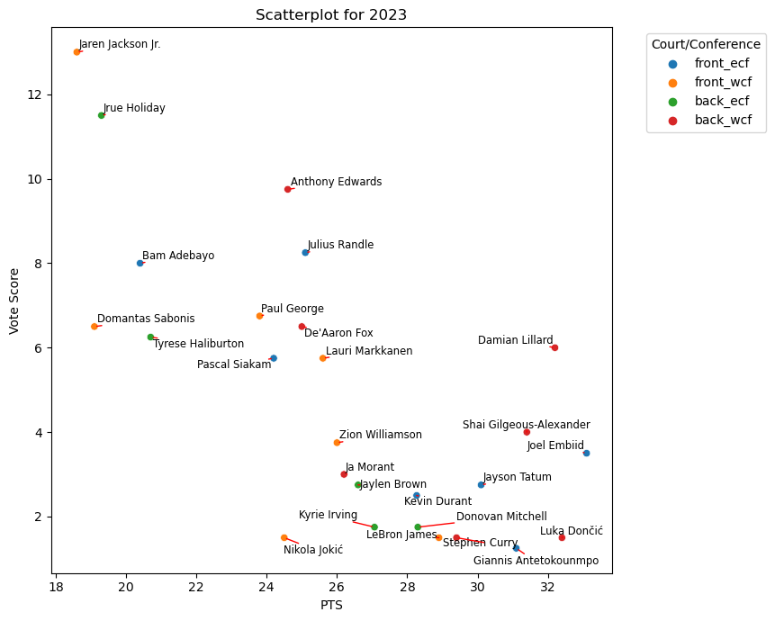

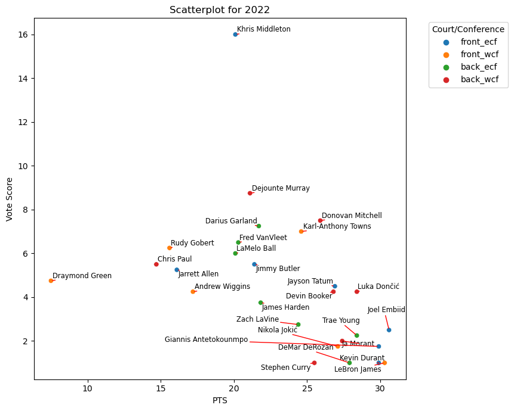

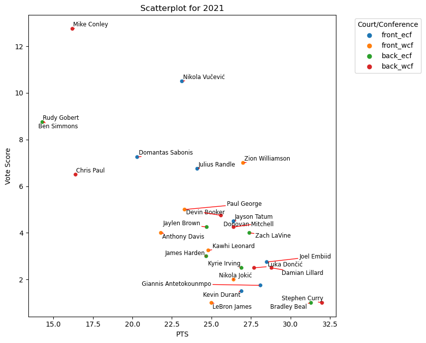

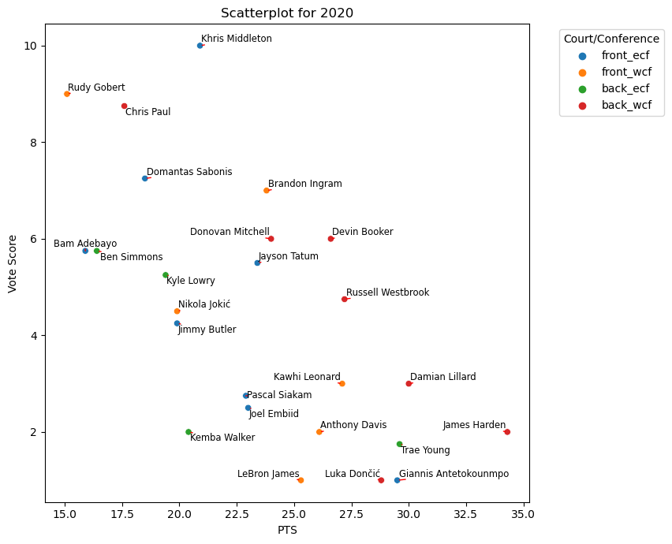

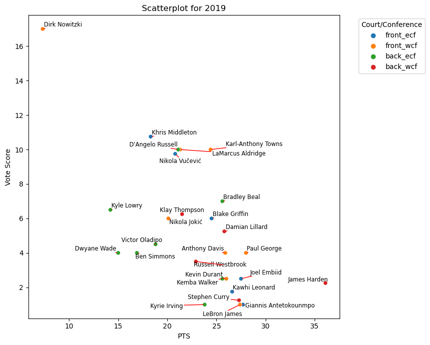

```python
years = ['2023', '2022', '2021', '2020', '2019']
combined_dfs = {}

for year in years:
    yearly_dfs = [df_dict[key] for key in df_dict if year in key]
    identifiers = [key.replace(f"_{year}", "") for key in df_dict if year in key]

    for df, identifier in zip(yearly_dfs, identifiers):
        df['Identifier'] = identifier

    combined_dfs[year] = pd.concat(yearly_dfs, ignore_index=True)

for year, df in combined_dfs.items():
    plt.figure(figsize=(7, 7))
    p = sns.scatterplot(data=df, x='PTS', y='Vote Score', hue='Identifier', palette='tab10')

    texts = []
    for index, row in df.iterrows():
        texts.append(plt.text(row['PTS'], row['Vote Score'], row['Player'], size='small'))

    adjust_text(texts, arrowprops=dict(arrowstyle='-', color='red'))

    plt.title(f"Scatterplot for {year}")
    plt.xlabel("PTS")
    plt.ylabel("Vote Score")
    plt.tight_layout()
    plt.legend(title='Court/Conference', bbox_to_anchor=(1.05, 1), loc='upper left')
    plt.show()
```

Based on these initial plots compared to their peers, it's hard to solely conclude that an All-Star is based on one particular skill such as scoring. For example, Jarret Allen barely scored over 16 points as part of the eastern conference frontcourt in 2022, and Draymond Green had not scored even 10 points per game as part of the the western conference frontcourt in 2022. Compared to their peers who had been scoring at a much higher level, these players were still able to power through and gain the All-Star honors. If we look closely at Draymond's statistics though, he averaged 7.3 total rebounds and 7.0 assists. Though he isn't much of a scorer, his passing ability and allowing others to score points as well as securing rebounds to prevent others from scoring or getting second chance opportunity points may have enticed voters to vote for him as they see him as a crucial player contributing to his team's success. Moreover, there are completely arbitrary picks which cannot necessarily be reasoned by statistics alone. For example, the Dirk Nowitizki outlier in the 2019 western conference frontcourt is due to the NBA commissioner granting him All-Star status due to his contributions to the game even though his statistics and Vote Score was abysmal that year. Regardless, it is still in our best interest to be holistic and look at the entirety of a player's capability and not just one specific offensive statistic to determine the All-Star status.

As mentioned before, we now primarily will look at five main categories to describe a player's success when it comes to determining their All-Star success. Because it's hard to determine solely based on one category whether it be offensive or defense, we'll combine all five of these statistics into one new category based on the following formula and logic. In general, the way to win a basketball game is to have a higher score. PTS indicates how many points a player scores, so we'll let the multiplier for that be singular. For every other category, we'll allow the multipler to be by two. AST indicates that a player has assisted another player which accrued points, so it could either range from 2-4 points. For STL, BLK, and TRB, in good faith, we'll assume a steal has converted into at least two points, a block has saved two points, and an offensive rebound leads to at least two points or a defensive rebound saves at least two points. We'll add all these values up and then provide a new categorical score and then compare these values by creating scatterplots once again.

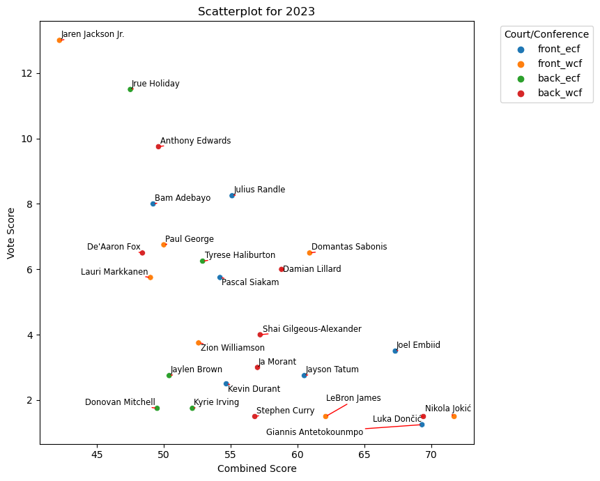

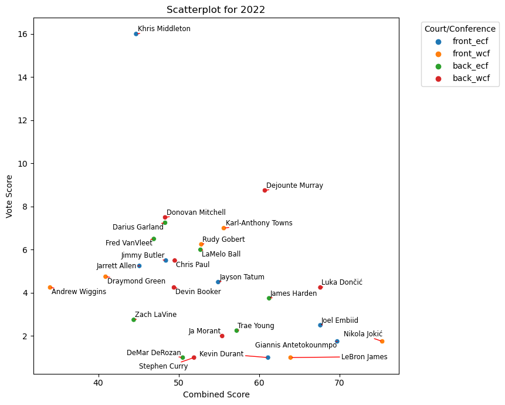

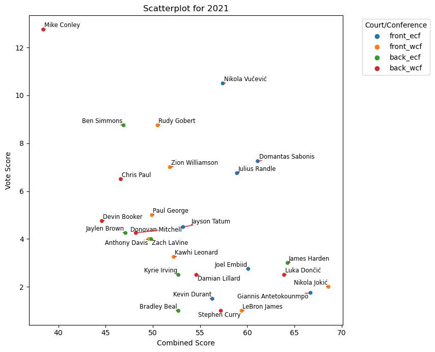

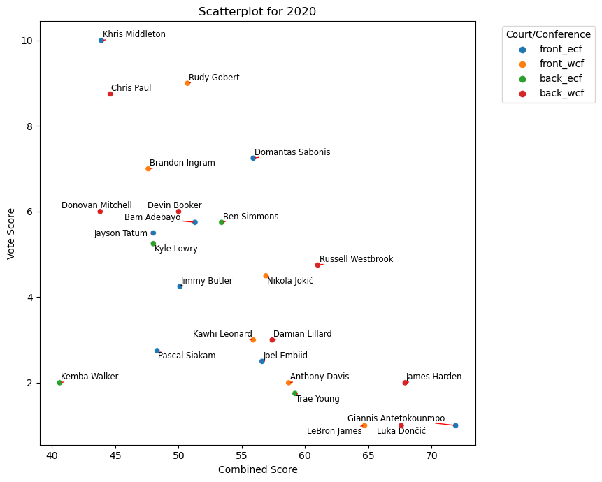

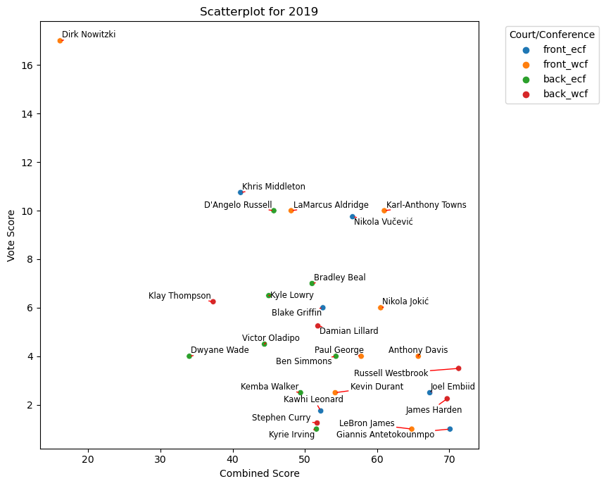

```python
for year, df in combined_dfs.items():
    df['Combined Score'] = df['PTS'] + 2 * (df['AST'] + df['STL'] + df['BLK'] + df['TRB'])
    plt.figure(figsize=(7, 7))
    p = sns.scatterplot(data=df, x='Combined Score', y='Vote Score', hue='Identifier', palette='tab10')

    texts = []
    for index, row in df.iterrows():
        texts.append(plt.text(row['Combined Score'], row['Vote Score'], row['Player'], size='small'))

    adjust_text(texts, arrowprops=dict(arrowstyle='-', color='red'))

    plt.title(f"Scatterplot for {year}")
    plt.xlabel("Combined Score")
    plt.ylabel("Vote Score")
    plt.tight_layout()
    plt.legend(title='Court/Conference', bbox_to_anchor=(1.05, 1), loc='upper left')
    plt.show()
```

Based on these scatterplots, the All-Star players are more congested on top of each other which we can say that perhaps their combined scores do provide a decent visual measure into telling us whether a larger combined score correlates with All-Star status.

### Preliminary Least Squares Model

Instead of solely utilizing scatterplots, let's start with creating a preliminary [least squares](https://www.statsmodels.org/devel/generated/statsmodels.regression.linear_model.OLS.html) model. Our model will be used to predict whether there is a linear correlation between one or more independent variables versus our dependent variable. In this case, a player's core five statistics are the independent variables while Vote Score is the dependent variable. Instead of directly using the Combined Score, we want to see how much of an impact each individual statistic of the five have most of an impact, so we'll clearly outline those within our formula. As an initial hypothesis, we predict that there is a linear correlation between these five core statistics and their vote score which translates to having more skill leads to a lower vote score.

```python
results = {}
for year, df in combined_dfs.items():
    temp_df = df.copy()

    X = temp_df[['PTS', 'AST', 'TRB', 'BLK', 'STL']]
    X['AST'] = 2 * X['AST']
    X['TRB'] = 2 * X['TRB']
    X['BLK'] = 2 * X['BLK']
    X['STL'] = 2 * X['STL']

    X = sm.add_constant(X)
    y = temp_df['Vote Score']

    model = sm.OLS(y, X).fit()
    results[year] = model

# Now, you can access the results for each year:
for year, result in results.items():
    print(f"Results for {year}:")
    print(result.summary())
    print("\n" + "-"*50 + "\n")
```

```
Results for 2023:
                            OLS Regression Results
==============================================================================
Dep. Variable:             Vote Score   R-squared:                       0.624
Model:                            OLS   Adj. R-squared:                  0.530
Method:                 Least Squares   F-statistic:                     6.644
Date:                Sun, 20 Aug 2023   Prob (F-statistic):           0.000852
Time:                        22:14:43   Log-Likelihood:                -54.528
No. Observations:                  26   AIC:                             121.1
Df Residuals:                      20   BIC:                             128.6
Df Model:                           5
Covariance Type:            nonrobust
==============================================================================
                 coef    std err          t      P>|t|      [0.025      0.975]
------------------------------------------------------------------------------
const         21.7215      4.256      5.104      0.000      12.844      30.599
PTS           -0.5274      0.106     -4.957      0.000      -0.749      -0.305
AST           -0.1611      0.126     -1.284      0.214      -0.423       0.101
TRB           -0.1223      0.103     -1.183      0.251      -0.338       0.093
BLK            0.4020      0.461      0.871      0.394      -0.560       1.364
STL            0.0115      0.875      0.013      0.990      -1.813       1.836
==============================================================================
Omnibus:                        1.414   Durbin-Watson:                   1.690
Prob(Omnibus):                  0.493   Jarque-Bera (JB):                1.161
Skew:                           0.492   Prob(JB):                        0.560
Kurtosis:                       2.680   Cond. No.                         316.
==============================================================================

Notes:
[1] Standard Errors assume that the covariance matrix of the errors is correctly specified.

--------------------------------------------------

Results for 2022:
                            OLS Regression Results
==============================================================================
Dep. Variable:             Vote Score   R-squared:                       0.401
Model:                            OLS   Adj. R-squared:                  0.259
Method:                 Least Squares   F-statistic:                     2.814
Date:                Sun, 20 Aug 2023   Prob (F-statistic):             0.0426
```

[output cut: 109 more lines]

```
AST           -0.2826      0.149     -1.900      0.071      -0.592       0.027
TRB            0.1125      0.139      0.809      0.427      -0.177       0.402
BLK           -0.7790      0.854     -0.913      0.372      -2.554       0.996
STL           -0.8357      0.767     -1.090      0.288      -2.430       0.759
==============================================================================
Omnibus:                        1.148   Durbin-Watson:                   1.451
Prob(Omnibus):                  0.563   Jarque-Bera (JB):                0.875
Skew:                           0.100   Prob(JB):                        0.646
Kurtosis:                       2.141   Cond. No.                         144.
==============================================================================

Notes:
[1] Standard Errors assume that the covariance matrix of the errors is correctly specified.

--------------------------------------------------
```

If we take a look at some of the statistics from our OLS Regression models, we can perhaps see some patterns. The important statistics are as following:

1. **coef**: the change in the dependent variable for a one-unit change in the predictor variable.
2. **R-Squared**: the proportion of the variance in the dependent variable that is predictable from the independent variables.
3. **P >|t|**: the p-value associated with the t-statistic for testing the hypothesis

If we look at the years, it seems that PTS have the lowest p-value which range around 0 in 2023 and 2021, 0.019 in 2022, 0.003 in 2020, and 0.011 in 2019. This is much different compared to the other categories. For example, the p-value for STL is all over the place from being 0.99 in 2023 which we can conclude that players were most likely not chosen as an All-Star for their STL statistic but in 2021 was 0.066 which we could conclude that a player's STL statistic was more effective and impactful.

Moreover, if we look at the coefficients, we can sometimes see smaller negative coefficients for some statistics such as BLK in years such as 2022 and 2021, but they are positive in 2023. The one thing to keep in mind about these coefficients is that PTS is consistently negative, and since the PTS category is a key factor in contributing towards their Combined Score, we can reasonably assume that players who do score a high amount generally have a lower voting score such that they will be more likely to be voted in as an All-Star.

To take a deeper look, we'll create some diagnostic plots which entail plotting residuals vs the fitted values. We'll also make a histogram as well to see how the distribution of residuals looks like. We assume that this distribution should be a normal distribution.

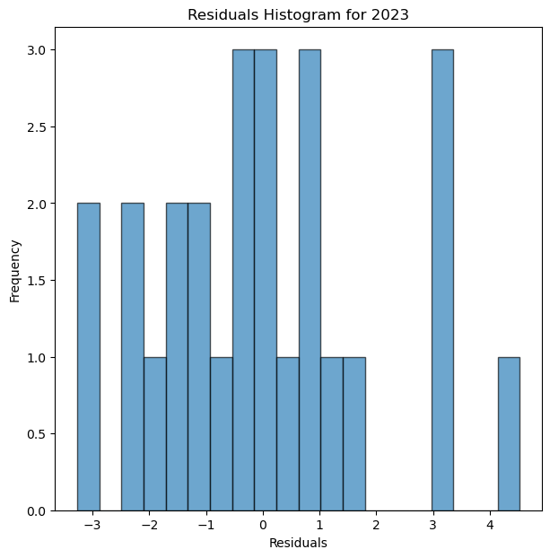

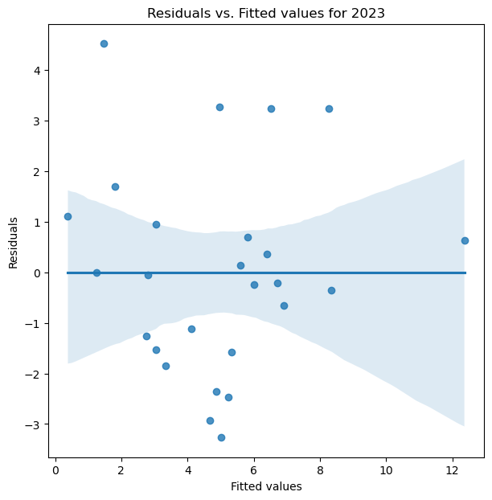

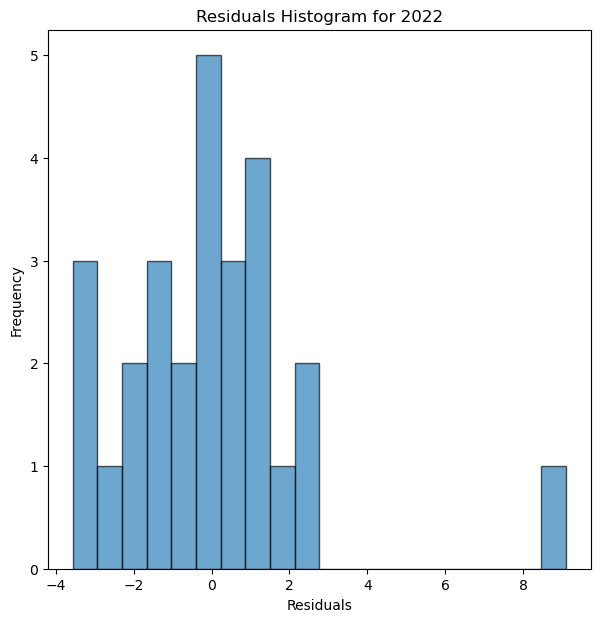

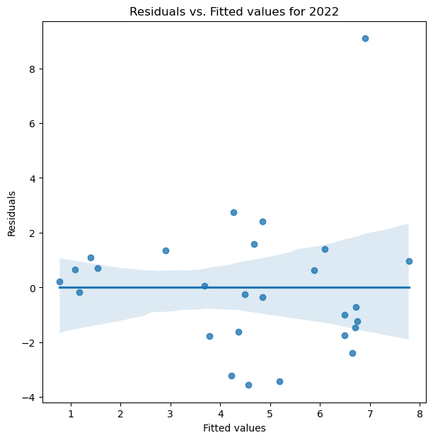

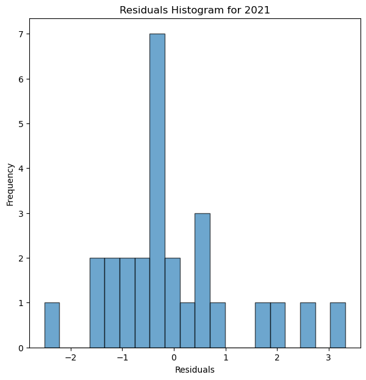

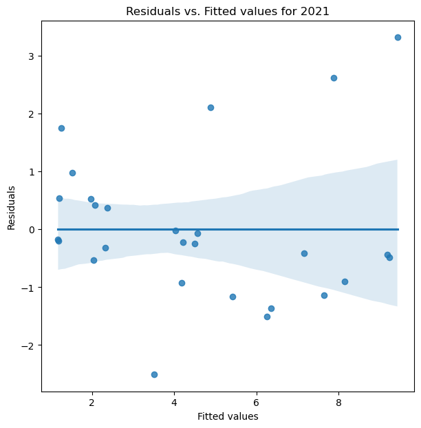

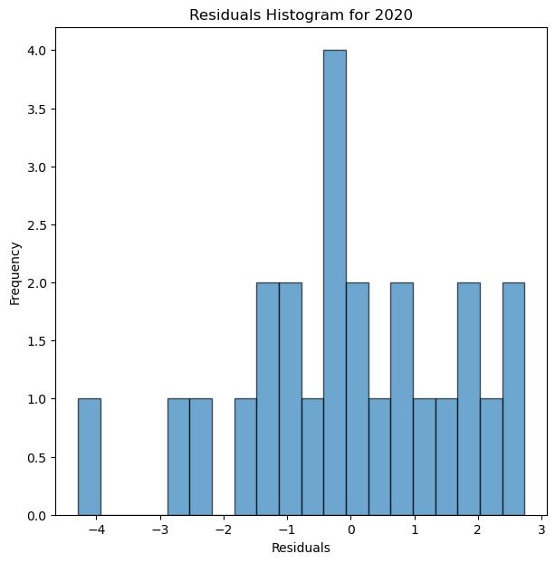

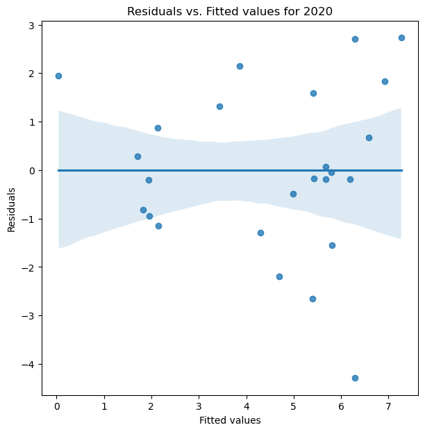

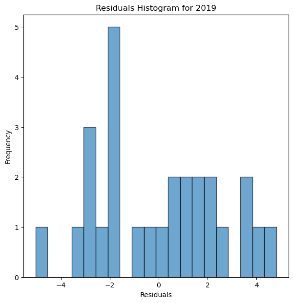

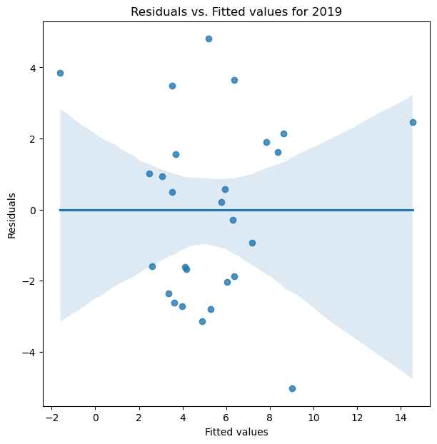

```python
for year, df in combined_dfs.items():
    X = df[['PTS', 'AST', 'TRB', 'BLK', 'STL']]
    X = sm.add_constant(X)
    y = df['Vote Score']
    model = sm.OLS(y, X).fit()

    residuals = model.resid
    fitted = model.fittedvalues

    plt.figure(figsize=(7, 7))
    plt.hist(residuals, bins=20, edgecolor='k', alpha=0.65)
    plt.title(f'Residuals Histogram for {year}')
    plt.xlabel('Residuals')
    plt.ylabel('Frequency')
    plt.show()

    plt.figure(figsize=(7, 7))
    sns.regplot(x=fitted, y=residuals, scatter=True)
    plt.title(f'Residuals vs. Fitted values for {year}')
    plt.xlabel('Fitted values')
    plt.ylabel('Residuals')
    plt.show()
```

We'll also do some time-series analysis to understand the trends amongst all years as most of the scatterplots have specifically looked the individual years.

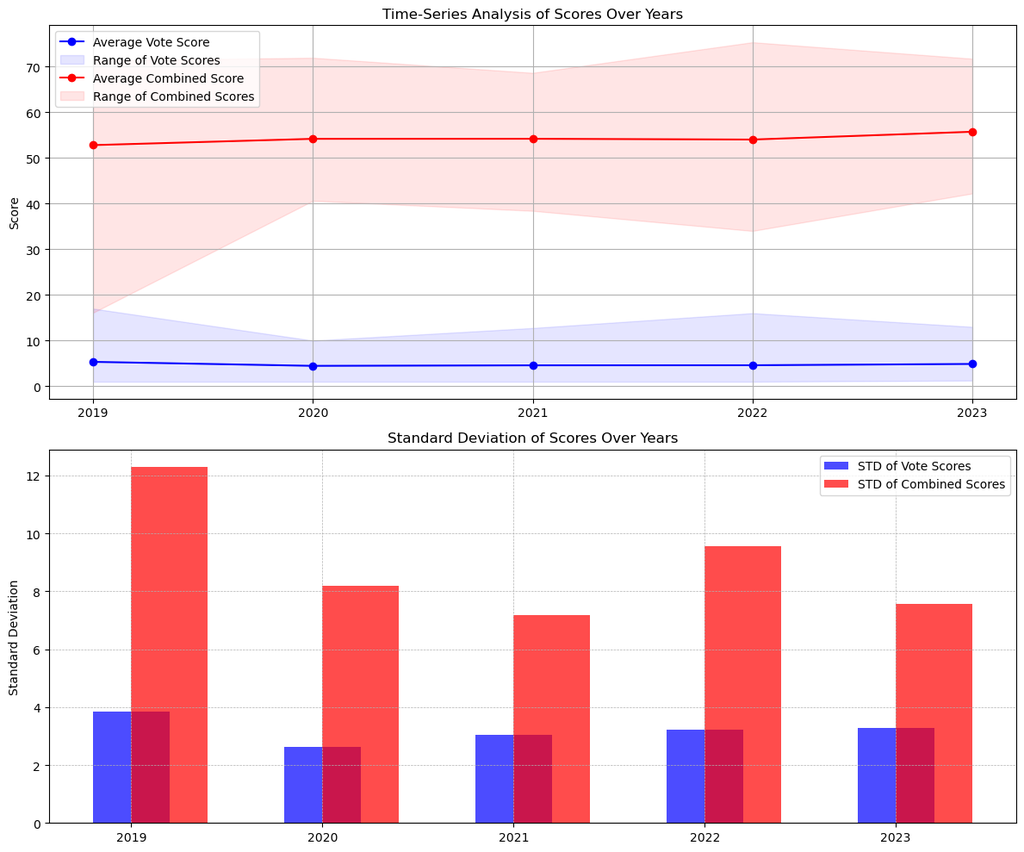

```python
years = ['2019', '2020', '2021', '2022', '2023']

avg_vote_scores = [combined_dfs[year]['Vote Score'].mean() for year in years]
std_vote_scores = [combined_dfs[year]['Vote Score'].std() for year in years]
min_vote_scores = [combined_dfs[year]['Vote Score'].min() for year in years]
max_vote_scores = [combined_dfs[year]['Vote Score'].max() for year in years]

avg_combined_scores = [combined_dfs[year]['Combined Score'].mean() for year in years]
std_combined_scores = [combined_dfs[year]['Combined Score'].std() for year in years]
min_combined_scores = [combined_dfs[year]['Combined Score'].min() for year in years]
max_combined_scores = [combined_dfs[year]['Combined Score'].max() for year in years]

fig, ax = plt.subplots(2, 1, figsize=(12,10))
ax[0].plot(years, avg_vote_scores, marker='o', label='Average Vote Score', color='blue')
ax[0].fill_between(years, min_vote_scores, max_vote_scores, color='blue', alpha=0.1, label='Range of Vote Scores')
ax[0].plot(years, avg_combined_scores, marker='o', label='Average Combined Score', color='red')
ax[0].fill_between(years, min_combined_scores, max_combined_scores, color='red', alpha=0.1, label='Range of Combined Scores')
ax[0].set_title('Time-Series Analysis of Scores Over Years')
ax[0].set_ylabel('Score')
ax[0].legend(loc='upper left')
ax[0].grid(True)
ax[1].bar(years, std_vote_scores, width=0.4, align='center', label='STD of Vote Scores', color='blue', alpha=0.7)
ax[1].bar(years, std_combined_scores, width=0.4, align='edge', label='STD of Combined Scores', color='red', alpha=0.7)
ax[1].set_title('Standard Deviation of Scores Over Years')
ax[1].set_ylabel('Standard Deviation')
ax[1].legend()
ax[1].grid(True, which='both', linestyle='--', linewidth=0.5)

plt.tight_layout()
plt.show()
```

Now, we're going to use [principal component analysis (PCA)](https://scikit-learn.org/stable/modules/generated/sklearn.decomposition.PCA.html). Perhaps instead of using our combined score metric to visually explore the impact and use assumptions, we can use PCA to combine all five of the main categories that we want into two principal components which measure the highest variance of the data. PC1 captures the highest variance while PC2 is orthogonal to PC1 which captures the second most variance.

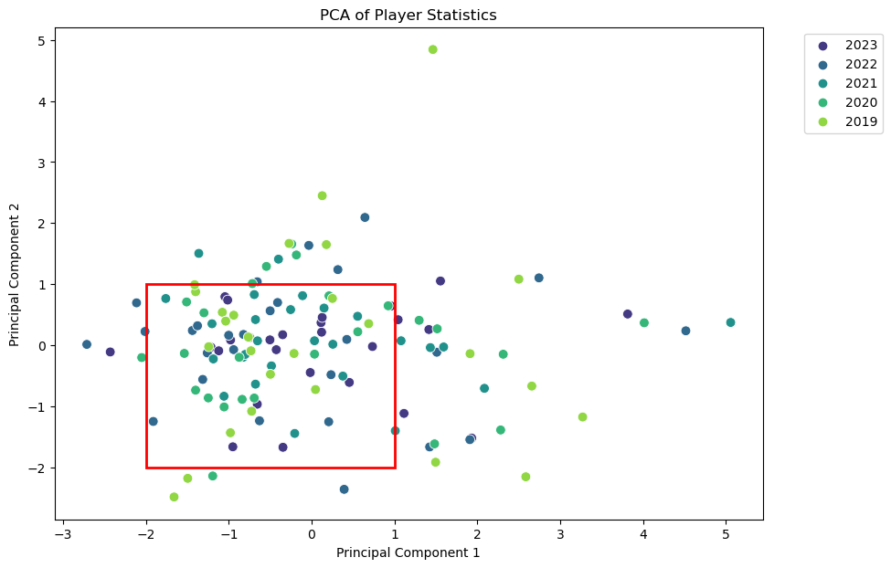

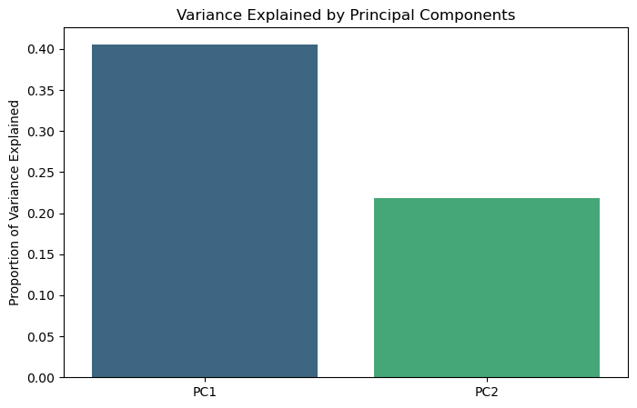

```python
for year, df in combined_dfs.items():
    df['year'] = year

all_years_df = pd.concat(combined_dfs.values(), ignore_index=True)
x = all_years_df[['PTS', 'AST', 'TRB', 'BLK', 'STL']]
x = StandardScaler().fit_transform(x)

pca = PCA(n_components=2)
principalComponents = pca.fit_transform(x)

principalDf = pd.DataFrame(data=principalComponents, columns=['PC1', 'PC2'])
principalDf['year'] = all_years_df['year']
plt.figure(figsize=(10,7))
sns.scatterplot(x='PC1', y='PC2', hue='year', data=principalDf, palette='viridis', s=60)

plt.gca().add_patch(plt.Rectangle((-2, -2), 3, 3, fill=False, edgecolor='red', linewidth=2))

plt.title('PCA of Player Statistics')
plt.xlabel('Principal Component 1')
plt.ylabel('Principal Component 2')
plt.legend(bbox_to_anchor=(1.05, 1), loc='upper left')
plt.show()

explained_variance = pca.explained_variance_ratio_
plt.figure(figsize=(8,5))
sns.barplot(x=['PC1', 'PC2'], y=explained_variance, palette='viridis')
plt.title('Variance Explained by Principal Components')
plt.ylabel('Proportion of Variance Explained')
plt.show()
```

## Model: Analysis, hypothesis testing, & ML

We now create use simple machine learning, more specifically [linear regression](https://scikit-learn.org/stable/modules/generated/sklearn.linear_model.LinearRegression.html), to obtain a predictive model to see who the All-Stars are going to be for 2024. This will allow us to predict based on our previous values from the past 5 years and see who is most likely going to be an All-Star. Although mentioned earlier that All-Stars are based on their positions and frontcourts, there are often times where players switch around positions to accommodate their team. Instead of worrying about the variability regarding that, we'll take a threshold of the top players which qualify and then present them below.

```python
for year, df in combined_dfs.items():
    df['Combined Score'] = df['PTS'] + 2 * (df['AST'] + df['STL'] + df['BLK'] + df['TRB'])

all_years = ['2019', '2020', '2021', '2022', '2023']
data = [combined_dfs[year]['Combined Score'].mean() for year in all_years]

# Extracting the information to use for Linear Regression using the Combined Score
X = np.array([int(year) for year in all_years]).reshape(-1, 1)
y = np.array(data)

# Linear Regression Model
model = LinearRegression().fit(X, y)
all_star_benchmark_2024 = model.predict(np.array([[2024]]))[0]

player_predictions = {}

dfs_list = [df2019, df2020, df2021, df2022, df2023]

# Fixing up the Combined Score columns due to some inconsistencies
for df in dfs_list:
    for index, row in df.iterrows():
        combined_score = float(row['PTS']) + 2 * (float(row['AST']) + float(row['STL']) + float(row['BLK']) + float(row['TRB']))
        df.at[index, 'Combined Score'] = combined_score

df2019, df2020, df2021, df2022, df2023 = dfs_list

player_predictions = {}

dfs_list = [df2019, df2020, df2021, df2022, df2023]

# Iterating through the dfs_list and then writing down the predictions for each player
for i, year_df in enumerate(dfs_list):
    year = 2019 + i
    for _, row in year_df.iterrows():
        player = row['Player']
        year_df['Combined Score'] = year_df['PTS'] + 2 * (year_df['AST'] + year_df['STL'] + year_df['BLK'] + year_df['TRB'])

        if player not in player_predictions:
            player_predictions[player] = {'years': [], 'scores': []}

        player_predictions[player]['years'].append(year)
        player_predictions[player]['scores'].append(row['Combined Score'])

predicted_scores_2024 = {}

# Based on the predictions, we then create Linear Regression models to fit which then give us a value to see
# the highest contributing players.
for player, data in player_predictions.items():
    years_played = len(data['years'])

    if years_played == 1:
        predicted_scores_2024[player] = data['scores'][0]
    else:
        X = np.array(data['years']).reshape(-1, 1)
        y = np.array(data['scores'])
        player_model = LinearRegression().fit(X, y)
        predicted_scores_2024[player] = player_model.predict(np.array([[2024]]))[0]

# Taking the highest valued players
players_2023 = set(df2023['Player'])
filtered_predictions_2024 = {player: score for player, score in predicted_scores_2024.items() if player in players_2023}
sorted_predictions_2024 = sorted(filtered_predictions_2024.items(), key=lambda x: x[1], reverse=True)
predicted_allstars_2024 = sorted_predictions_2024[:24]
df_predicted_allstars_2024 = pd.DataFrame(predicted_allstars_2024, columns=['Player', 'Predicted Combined Score'])
df_predicted_allstars_2024
```

|  | Player | Predicted Combined Score |
| --- | --- | --- |
| 0 | Nikola Jokić | 78.840000 |
| 1 | Luka Dončić | 74.700000 |
| 2 | Giannis Antetokounmpo | 68.400000 |
| 3 | Jayson Tatum | 67.490000 |
| 4 | Domantas Sabonis | 67.466667 |
| 5 | Joel Embiid | 67.080000 |
| 6 | Shai Gilgeous-Alexander | 65.930000 |
| 7 | Tyrese Haliburton | 63.522222 |
| 8 | Ja Morant | 63.400000 |
| 9 | LaMelo Ball | 63.233333 |
| 10 | LeBron James | 61.120000 |
| 11 | Dejounte Murray | 59.900000 |
| 12 | Trae Young | 59.500000 |
| 13 | Pascal Siakam | 59.270000 |
| 14 | Alperen Şengün | 59.200000 |
| 15 | Julius Randle | 58.340000 |
| 16 | Kevin Durant | 58.284762 |
| 17 | Jaylen Brown | 57.790000 |
| 18 | Stephen Curry | 57.430000 |
| 19 | Bam Adebayo | 57.340000 |
| 20 | Zion Williamson | 57.242857 |
| 21 | Darius Garland | 56.600000 |
| 22 | Damian Lillard | 55.900000 |
| 23 | Desmond Bane | 55.733333 |

After witnessing the model and the outputs, we can safely say that the model is mostly accurate and its predictions seem accurate. Domantas Sabonis is a little bit high as opposed to his peers in the rankings, but he was an All-Star and is still definitely All-Star caliber and can flourish in the next season with the Sacramento Kings. However, there are some odd choices our model spit out such as Alperen Şengün. Though he did have a solid season in terms of rebounding and a decent amount of points, he definitely doesn't seem to have that much fan interest within the NBA as well, but perhaps the model overvalued him based on only two of his seasons. He is also respected as one of the most brightest Turkish prospects to reach the NBA as well. Desmond Bane is also another odd pick, but he did also have a great season within his third year averaging over 20 points per game, 5 total rebounds, and 4.4 assists per game.

## Step 5: Interpretation: Insight & Policy Decision

However, there are many other factors which also lead to being voted in as an All-Star which include external influences such as Instagram followers and popularity off the court. For someone such as LeBron James, it'd be a no-brainer he would be voted in every single time considering his amazing consistency and his following with over hundreds of millions of people through social media.

If we could conduct further research, it would be wise to not only understand statistics within basketball but also outside through social media followers considering half of the All-Star vote is dependent on the fans. As players interact more with the fans, this could be a major impact regarding how Instagram followers could also be dependent to measure the vote.

Moreover, different years have different methodologies of voting. For example, before 2017, the All-Star voting criteria was solely based on the fans, and so they took advantage of this and voted for a player, Zaza Pachulia, who definitely was not up to the standards as opposed to the regular All-Star caliber player. Hence, this study could be completely different and maybe more dependent on other factors such as popularity rather than on-court performance as opposed to now where players and media also have a say in who is an All-Star.

From seeing this study, I hope you have learned something and also come back to see whether my predictions are correct. Hopefully the data science lifecycle is present starting from data collection, data processing, exploratory analysis & data visualizations, model: analysis, hypothesis testing & ml, and the interpretation.

### Bibliography

Image Source:  
**https://img.bleacherreport.net/img/images/photos/003/724/927/hi-res-eabc84bc6f36b4c6a7532aca7c8e50f5_crop_exact.jpg?w=1200&h=1200&q=75**

Relevant NBA All-Star Voting Articles  
https://bleacherreport.com/articles/10061451-nba-all-star-game-2023-lebron-james-kevin-durant-lead-2nd-voting-results  
https://www.sbnation.com/nba/2023/1/5/23541022/nba-all-star-fan-voting-results-east-west-starters-right-wrong  
https://apnews.com/article/phoenix-suns-nba-sports-basketball-chet-holmgren-2522d627bd74debe9f939bd2ec374bef

Relevant Data Science Articles/Links  
https://pandas.pydata.org/docs/user_guide/index.html#user-guide  
http://www.stat.yale.edu/Courses/1997-98/101/linreg.htm  
https://mathworld.wolfram.com/LeastSquaresFitting.html  
https://towardsdatascience.com/a-one-stop-shop-for-principal-component-analysis-5582fb7e0a9c  
https://www.simplilearn.com/tutorials/statistics-tutorial/hypothesis-testing-in-statistics